# Vectors

We will introduce the basic objects of study in linear algebra and operations on them. We first define the notion of a **field**: a set on which addition, subtraction, multiplication, and division are defined. The most common fields are the set of real numbers $\mathbb R$, the set of complex numbers $\mathbb C$, and the set of rational numbers $\mathbb Q$. Elements of fields are called **scalars**.

We mostly deal with $\mathbb R$ in this course, with $\mathbb C$ popping up in a few places. A **vector** can be defined as a *list* of scalars, e.g. $\mathbf v = (1,2,3)$ or $\mathbf w = (3,2,1)$. Note that order matters; $\mathbf v$ and $\mathbf w$ are different vectors (if order does not matter, these would be sets). A vector thus represents multiple scalar quantities at once.

The **dimension** of a vector is the number of elements that it contains. If $\mathbf v$ contains 3 elements, we may say that it has dimension 3, that it is a 3-dimensional vector, or more simply that it is a 3-vector. The set of all $n$-vectors is denoted $\mathbb R^n$. We can thus say that $\mathbf v \in \mathbb R^3$.

Vectors may be defined as 1D NumPy arrays as follows:

```python
# standard import statement for the numpy library
# you should run this line every time you open a Colab notebook
import numpy as np

# call the array() function to define and return a numpy array
v = np.array([1,2,3])   # argument may be a Python list
w = np.array((3,2,1))   # argument may also be a tuple

print("v =", v)
print("w =", w)
print("dimension of v is", v.size)  # useful attribute for vector size
```

```
v = [1 2 3]
w = [3 2 1]
dimension of v is 3
```

# Column Vectors and Row Vectors

We wrote the vector examples above as lists surrounded by parentheses and separated by commas. More generally, these are equivalent to **columm vectors**, which is the default vector representation unless otherwise specified:

$$ \mathbf v = \begin{bmatrix} 1 \\ 2 \\ 3 \end{bmatrix}, \quad \mathbf w = \begin{bmatrix} 3 \\ 2 \\ 1 \end{bmatrix} $$

The "parentheses and commas" representation saves a lot of space, which is why it may be preferable unless we are working with matrices and vectors together. Column vectors are *different* from **row vectors**. For example, the row vector

$$ \mathbf u = \begin{bmatrix} 1 & 2 & 3 \end{bmatrix} $$

is not the same as $\mathbf v$. Note that $\mathbf u$ is written using brackets, and moreover commas are not present. $\mathbf v$ and $\mathbf u$ *do* have the same ordered elements, and they are related by the **transpose** operation: $\mathbf v = \mathbf u^\top$, $\mathbf u = \mathbf v^\top$. In other words, transposing a column vector turns it into a row vector and vice-versa.

**IMPORTANT:** NumPy does not differentiate between column and row vectors. It prints out 1D arrays as row vectors (as you may have noticed above), but otherwise all operations that we define for vectors will work in the same way.

```python
print("v.T =", v.T)  # transpose operation does not do anything here
```

```
v.T = [1 2 3]
```

# Notation and Indexing

There are many different ways to denote vectors and their names. In this class, we will use bold font to denote vectors. Non-bolded lower-case variables or Greek letters will typically denote scalars. Note that we may deal with *multiple* vectors at once, in which case we can use subscripts to identify them: $\mathbf v_1, \mathbf v_2, \mathbf v_3, \ldots$

We may also *index* vectors to access individual components. Confusingly, a subscript is usually used for this operation as well. We may revert back to non-bolded font to refer to these quantities. For example, taking $\mathbf v$ and $\mathbf w$ from the above, we have $v_1 = 1, w_2 = 2$, and so on. Please note that this is not universal notation, and that sometimes you will just have to rely on context to tell what is what.

**IMPORTANT:** In the indexing examples above, 1 refers to the first component. This is standard in most mathematical contexts. However, you may remember that Python and many other programming languages start indexing at 0. Indexing in Python and NumPy is done using brackets:

```python
print("v[0] =", v[0])
print("w[1] =", w[1])
print("v[2] =", v[-1])  # negative indices may be used to start indexing from the end
print("w[1] =", w[-2])
```

```
v[0] = 1
w[1] = 2
v[2] = 3
w[1] = 2
```

More than just individual components, NumPy is able to extract multiple components of a vector at once using creative indexing. For example, we can input a list of indices instead of a single index inside the brackets.

```python
w = np.array([1,4,-5,2,-7,8])
print("0th, 2nd, and 5th components of w:", w[[0,2,5]])
```

```
0th, 2nd, and 5th components of w: [ 1 -5  8]
```

Even more powerful is the usage of the `:` (colon) operator, which indicates range.

```python
print("1st up to (but not including) 4th components:", w[1:4])
print("starting index defaults to 0 if not given", w[:4])
print("end index defaults to last if not given", w[3:])
```

```
1st up to (but not including) 4th components: [ 4 -5  2]
starting index defaults to 0 if not given [ 1  4 -5  2]
end index defaults to last if not given [ 2 -7  8]
```

If two `:` operators are used, then the third number indicates *interval*, such as every second component, or every third. The first two still indicate starting and ending index. Any of these may be omitted if the default indices are desired.

```python
print("every 2 components between 1st and 4th components:", w[1:4:2])
print("every 2 components between 0th and 4th components:", w[:4:2])
print("every 3 components between 3rd and last components:", w[3::3])
```

```
every 2 components between 1st and 4th components: [4 2]
every 2 components between 0th and 4th components: [ 1 -5]
every 3 components between 3rd and last components: [2]
```

# Manipulation (NumPy)

As with many other data types, NumPy arrays are *mutable*, which means they can be modified after they are defined. For example, we can change array entries using indexing. Simply place the part of the array you want to change on the LHS of an equals sign, and place the new values on the RHS. The sizes on either side must be the same, with the exception that if the RHS is a scalar, the same value is applied to all entries on the LHS.

```python
w[0] = 0            # set 0th element to 0
w[[2,4]] = [-2,-4]  # set 2nd and 4th elements to -2 and -4
w[1::2] = -1        # set every 2 elements starting from 1st one to -1
print(w)
```

```
[ 0 -1 -2 -1 -4 -1]
```

NumPy also allows you to add or delete entries from an array, or concatenate two arrays together. There are a number of different [functions](https://numpy.org/doc/stable/reference/routines.array-manipulation.html) that allow you to do this. We'll show the most commonly used ones for 1D arrays (vectors) and revisit some of these when discuss 2D arrays (matrices).

```python
print(np.append(v, 10))       # append 10 to the end of v
print(np.append(v, [10,11]))  # append the array [10,11] to v (still returns one array)
print(np.insert(v, 1, -1))    # insert -1 into the 1 component of v
print(np.delete(v, 1))        # delete entry in the 1 component of v
```

```
[ 1  2  3 10]
[ 1  2  3 10 11]
[ 1 -1  2  3]
[1 3]
```

# Special Vectors

Certain vectors appear often in different contexts that it is useful to give them a name and a special way to define them in NumPy. For example, the **zero vector** is a $n$-vector of all 0s, denoted $\mathbf 0_n$ or just $\mathbf 0$. The **ones vector** is a $n$-vector of all 1s, denoted $\mathbf 1_n$ or just $\mathbf 1$.

For many programming tasks, we may have to generate a vector of evenly spaced values within a certain interval. This may be accomplished using `numpy.arange` or `numpy.linspace`.

```python
print("A 3-dim zeros vector:", np.zeros(3))
print("A 5-dim ones vector:", np.ones(5))

print(np.arange(8))         # arange with 1 argument: values 0 to 8 with interval 1
print(np.arange(3,8))       # arange with 2 arguments: values 3 to 8 with interval 1
print(np.arange(3,8,2))     # arange with 3 arguments: values 3 to 8 with interval 2
print(np.linspace(3,8))     # linspace with 2 arguments: 50 (default) values from 3 to 8
print(np.linspace(3,8,10))  # linspace with 3 arguments: 10 values from 3 to 8
```

```
A 3-dim zeros vector: [0. 0. 0.]
A 5-dim ones vector: [1. 1. 1. 1. 1.]
[0 1 2 3 4 5 6 7]
[3 4 5 6 7]
[3 5 7]
[3.         3.10204082 3.20408163 3.30612245 3.40816327 3.51020408
 3.6122449  3.71428571 3.81632653 3.91836735 4.02040816 4.12244898
 4.2244898  4.32653061 4.42857143 4.53061224 4.63265306 4.73469388
 4.83673469 4.93877551 5.04081633 5.14285714 5.24489796 5.34693878
 5.44897959 5.55102041 5.65306122 5.75510204 5.85714286 5.95918367
 6.06122449 6.16326531 6.26530612 6.36734694 6.46938776 6.57142857
 6.67346939 6.7755102  6.87755102 6.97959184 7.08163265 7.18367347
 7.28571429 7.3877551  7.48979592 7.59183673 7.69387755 7.79591837
 7.89795918 8.        ]
[3.         3.55555556 4.11111111 4.66666667 5.22222222 5.77777778
 6.33333333 6.88888889 7.44444444 8.        ]
```

# Visualizing Vectors

Vectors of arbitrary dimension can be defined easily by just writing down a list with many elements. We can also visualize 2-vectors and 3-vectors as points or arrows in 2D and 3D space (but no higher). A vector's elements define the coordinates of a point in the standard coordinate system, so we can equate that point with the vector itself.

Thinking of a vector as an arrow, we can place the *tail* of the arrow at the origin and the *head* of the arrow at the coordinates specified by the vector elements. Note that there is nothing special about starting at the origin; once we know the *direction* of the vector, it is also possible to move it around while keeping the direction the same.

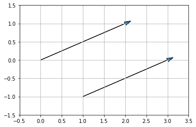

```python
# library that you will often use for plotting objects
import matplotlib.pyplot as plt

a = np.array([2,1])
plt.arrow(0, 0, a[0], a[1], head_width=.1)  # plotting a as an arrow from the origin
plt.arrow(1, -1, a[0], a[1], head_width=.1) # same vector, but from (1,-1)
plt.axis([-0.5,3.5,-1.5,1.5])
plt.grid()
```